# Data Binning

## Data Binning

Data binning, also known as discretization or bucketing, is a process of grouping a set of continuous or numerical data points into a smaller number of discrete "bins" or intervals.

```python
import pandas as pd
import numpy as np
import matplotlib.pyplot as plt
from sklearn.cluster import KMeans
import seaborn as sns

# Create a sample dataset of ages
np.random.seed(42)  # for reproducibility
ages = np.random.randint(18, 65, 100)  # generating 100 random ages between 18 and 65
df = pd.DataFrame({'Age': ages})

# Display the initial dataset
print("Initial Dataset:")
print(df.head(10))  # Displaying the first 10 rows
```

```
Initial Dataset:
   Age
0   56
1   46
2   32
3   60
4   25
5   38
6   56
7   36
8   40
9   28
```

```python
df.shape
```

```
(100, 1)
```

### 1. Equal Width Binning (Uniform Binning):

```python
# Binning using equal width
df['Age_Bin_EqualWidth'] = pd.cut(df['Age'], bins=5)

# Display the result
print("\nAfter Equal Width Binning:")
print(df[['Age', 'Age_Bin_EqualWidth']].head(10))
```

```
After Equal Width Binning:
   Age Age_Bin_EqualWidth
0   56       (54.8, 64.0]
1   46       (45.6, 54.8]
2   32       (27.2, 36.4]
3   60       (54.8, 64.0]
4   25     (17.954, 27.2]
5   38       (36.4, 45.6]
6   56       (54.8, 64.0]
7   36       (27.2, 36.4]
8   40       (36.4, 45.6]
9   28       (27.2, 36.4]
```

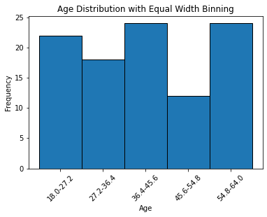

```python
# Plotting the histogram
plt.hist(df['Age'], bins=5, edgecolor='black')
plt.title('Age Distribution with Equal Width Binning')
plt.xlabel('Age')
plt.ylabel('Frequency')

# Adding bin labels
bin_labels = [f'{bin.left:.1f}-{bin.right:.1f}' for bin in df['Age_Bin_EqualWidth'].cat.categories]
plt.xticks([(bin.left + bin.right) / 2 for bin in df['Age_Bin_EqualWidth'].cat.categories], bin_labels, rotation=45)

# Display the plot
plt.show()
```

1. Question: What is equal width binning, and why is it used in data preprocessing?

Answer: Equal width binning is a data preprocessing technique that involves dividing a continuous variable into intervals of equal width. It is used to simplify the analysis of continuous data by grouping values into discrete bins, making it easier to interpret and analyze trends within the data.

1. Question: How do you determine the number of bins for equal width binning?

Answer: The number of bins can be determined by various methods, such as the square root rule (number of bins is the square root of the total number of data points) or Sturges' formula (number of bins is log2(N) + 1, where N is the number of data points).

1. Question: What are the potential drawbacks of equal width binning?

Answer: Equal width binning may lead to loss of information and sensitivity to outliers. If the data distribution is skewed, equal width binning may result in unevenly populated bins, and important patterns in the data may be obscured.

1. Question: Can you provide an example of how equal width binning is applied in a real-world scenario?

Answer: In finance, equal width binning can be used to categorize customers based on their income into income brackets, facilitating the analysis of spending patterns and risk assessment.

1. Question: How does equal width binning differ from equal frequency binning?

Answer: Equal width binning divides the data into intervals of equal width, while equal frequency binning divides the data into intervals such that each interval contains approximately the same number of data points.

1. Question: What considerations should be taken into account when applying equal width binning to time-series data?

Answer: When dealing with time-series data, it's important to consider the temporal aspect. Equal width binning may not be appropriate if there are seasonal trends or if the data has a time-dependent structure.

1. Question: How can equal width binning be sensitive to outliers, and how can this sensitivity be mitigated?

Answer: Equal width binning may result in wide bins that include outliers, impacting the analysis. To mitigate this, outliers can be handled separately or alternative binning methods that are less sensitive to extreme values can be considered.

1. Question: Are there cases where equal width binning is not suitable, and alternative methods should be considered?

Answer: Yes, equal width binning may not be suitable for data with a non-uniform distribution. In such cases, methods like equal frequency binning or custom binning based on domain knowledge may be more appropriate.

1. Question: How can the choice of bin width impact the results of equal width binning?

Answer: The bin width directly influences the granularity of the analysis. Choosing a smaller bin width increases the detail but may lead to overfitting, while a larger bin width may oversimplify the data.

1. Question: Can you discuss the impact of equal width binning on machine learning models?

Answer: Equal width binning can be beneficial for certain machine learning models that assume categorical input, as it converts continuous features into discrete categories. However, its impact may vary depending on the model and the nature of the data, and it's essential to consider alternative encoding methods in some cases.

### 2. Equal Frequency Binning:

Divides the data into intervals such that each bin contains approximately the same number of data points. This can help balance the distribution in each bin.

```python
# Binning using equal frequency
df['Age_Bin_EqualFreq'] = pd.qcut(df['Age'], q=5)

# Display the result
print("\nAfter Equal Frequency Binning:")
print(df[['Age', 'Age_Bin_EqualFreq']].head(10))
```

```
After Equal Frequency Binning:
   Age Age_Bin_EqualFreq
0   56      (43.0, 56.2]
1   46      (43.0, 56.2]
2   32      (26.0, 36.6]
3   60      (56.2, 64.0]
4   25    (17.999, 26.0]
5   38      (36.6, 43.0]
6   56      (43.0, 56.2]
7   36      (26.0, 36.6]
8   40      (36.6, 43.0]
9   28      (26.0, 36.6]
```

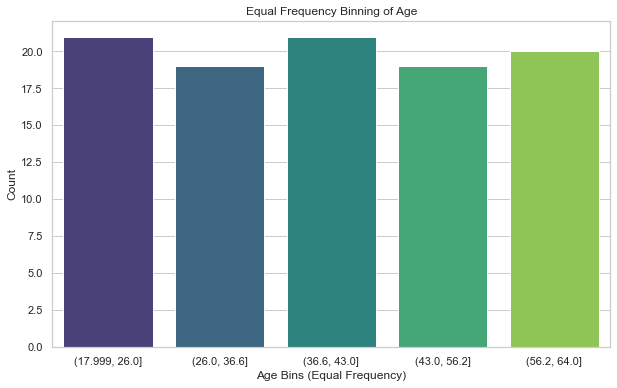

```python
plt.figure(figsize=(10, 6))
sns.countplot(x='Age_Bin_EqualFreq', data=df, palette='viridis')
plt.title('Equal Frequency Binning of Age')
plt.xlabel('Age Bins (Equal Frequency)')
plt.ylabel('Count')
plt.show()
```

1. Question: What is equal frequency binning, and how does it differ from equal width binning?

Answer: Equal frequency binning is a data preprocessing technique that divides a continuous variable into intervals such that each interval contains roughly the same number of data points. Unlike equal width binning, which divides the range of values into intervals of equal width, equal frequency binning focuses on distributing data points equally across bins.

1. Question: What are the advantages of using equal frequency binning in data analysis?

Answer: Equal frequency binning helps maintain the distribution of the original data and ensures that each bin represents a consistent proportion of the dataset. This can be particularly useful when dealing with skewed datasets or when the goal is to capture variations in the tails of the distribution.

1. Question: How do you determine the number of bins for equal frequency binning?

Answer: The number of bins can be determined by specifying the desired frequency for each bin. For example, if you want to create quartiles, you would have four bins, each containing approximately 25% of the data.

1. Question: Can you discuss a scenario where equal frequency binning is preferable over equal width binning?

Answer: Equal frequency binning is preferable when dealing with datasets where the distribution is uneven, and there are outliers. It helps in maintaining the representation of extreme values in separate bins, providing a more accurate reflection of the data distribution.

1. Question: How does equal frequency binning handle outliers, and what are its limitations in this regard?

Answer: Equal frequency binning does not treat outliers separately, and they may be included in the same bin as other data points. This can be a limitation, as outliers might impact the analysis, and other techniques or preprocessing steps may be needed to address this issue.

1. Question: In what situations might equal frequency binning not be the best choice?

Answer: Equal frequency binning may not be suitable for datasets with a uniform distribution, as it can result in bins that do not capture meaningful patterns. Additionally, it may not be appropriate when outliers are prevalent and need special attention.

1. Question: How can the choice of binning method (equal frequency vs. equal width) impact the interpretability of the analysis?

Answer: The choice of binning method affects the granularity of the analysis. Equal frequency binning provides bins with varying widths, which can be advantageous in capturing detailed patterns, especially in the tails of the distribution. However, it may also introduce complexity in interpretation.

1. Question: Can you discuss the computational complexity of implementing equal frequency binning compared to other binning methods?

Answer: Equal frequency binning may involve sorting the data to ensure an equal distribution of frequencies. This sorting step can introduce additional computational complexity, especially for large datasets. It's important to consider the trade-offs between computational cost and the benefits of maintaining data distribution.

1. Question: How does equal frequency binning impact the performance of machine learning models that rely on discretized features?

Answer: Equal frequency binning can be beneficial for certain machine learning models, especially those sensitive to variations in the tails of the distribution. However, like any binning method, it introduces discretization, and the impact on model performance may depend on the specific characteristics of the dataset and the algorithm used.

1. Question: Can you provide an example of a business application where equal frequency binning would be particularly relevant?

Answer: In credit scoring, equal frequency binning can be used to categorize individuals based on their credit scores into risk categories, ensuring that each category represents a similar proportion of the population. This allows for a more balanced assessment of credit risk across different segments of the population.

## Clustering-based binning.

```python
# Create a sample dataset of ages
np.random.seed(42)
ages = np.random.randint(18, 65, 100)
df = pd.DataFrame({'Age': ages})

# Display the initial dataset
print("Initial Dataset:")
print(df.head(10))

# Perform clustering-based binning using KMeans
kmeans = KMeans(n_clusters=5, random_state=42)
df['Age_Cluster'] = kmeans.fit_predict(df[['Age']])
```

```
Initial Dataset:
   Age
0   56
1   46
2   32
3   60
4   25
5   38
6   56
7   36
8   40
9   28
```

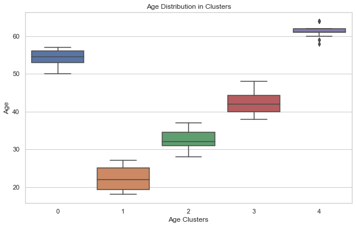

```python
# Box plot for each cluster
plt.figure(figsize=(10, 6))
sns.boxplot(x='Age_Cluster', y='Age', data=df)
plt.title('Age Distribution in Clusters')
plt.xlabel('Age Clusters')
plt.ylabel('Age')
plt.show()
```

```python
# Descriptive statistics for each cluster
cluster_stats = df.groupby('Age_Cluster')['Age'].describe()
print(cluster_stats)
```

```
             count       mean       std   min    25%   50%    75%   max
Age_Cluster
0             14.0  54.285714  2.334641  50.0  53.00  54.5  56.00  57.0
1             22.0  22.272727  3.010803  18.0  19.25  22.0  25.00  27.0
2             19.0  32.368421  2.543194  28.0  31.00  32.0  34.50  37.0
3             28.0  42.107143  2.910254  38.0  40.00  42.0  44.25  48.0
4             17.0  61.411765  1.839117  58.0  61.00  61.0  62.00  64.0
```

1. Question: What is clustering-based binning, and how does it differ from traditional binning methods?

Answer: Clustering-based binning is a technique that uses clustering algorithms to group similar data points together, forming natural clusters. These clusters are then used to define bins for continuous variables. Unlike traditional binning methods that rely on fixed intervals, clustering-based binning adapts to the data's inherent structure.

1. Question: Which clustering algorithms are commonly used for clustering-based binning, and how do they contribute to the binning process?

Answer: Common clustering algorithms for clustering-based binning include k-means, hierarchical clustering, and density-based clustering. These algorithms identify groups of similar data points, and the resulting clusters are used to define the bins.

1. Question: What are the advantages of using clustering-based binning in comparison to other binning methods?

Answer: Clustering-based binning can capture complex and non-linear relationships within the data, making it suitable for datasets with intricate patterns. It is less sensitive to outliers and can adapt to variations in data density, providing more nuanced insights.

1. Question: How do you determine the number of bins in clustering-based binning?

Answer: The number of bins in clustering-based binning is often determined by the number of clusters identified by the clustering algorithm. Selecting an optimal number of clusters can be done using techniques like the elbow method or silhouette analysis.

1. Question: Can clustering-based binning be applied to categorical data, or is it primarily for continuous variables?

Answer: Clustering-based binning is primarily designed for continuous variables, as it relies on measures of similarity between data points. However, similar principles can be applied to categorical variables using appropriate distance metrics for categorical data.

1. Question: How does clustering-based binning handle variable interactions and correlations within the dataset?

Answer: Clustering-based binning can capture variable interactions and correlations by considering the overall similarity of data points. If two variables are correlated, they are likely to end up in the same or neighboring clusters, influencing the binning outcome.

1. Question: What challenges might arise when using clustering-based binning, and how can they be addressed?

Answer: Challenges may include sensitivity to the choice of clustering algorithm and parameters, as well as the need to interpret the clusters. Addressing these challenges involves experimenting with different algorithms and parameters and validating the binning results against domain knowledge.

1. Question: Can you provide an example of a business scenario where clustering-based binning would be particularly useful?

Answer: In customer segmentation for marketing purposes, clustering-based binning can be applied to group customers based on their purchasing behavior, helping businesses tailor marketing strategies to specific customer segments with similar preferences.

1. Question: How does clustering-based binning contribute to feature engineering in machine learning?

Answer: Clustering-based binning can be used as a feature engineering technique to transform continuous variables into categorical ones, capturing underlying patterns in the data. This can enhance the performance of machine learning models, especially when relationships within the data are complex.

1. Question: When might clustering-based binning not be the best choice, and what alternative methods could be considered?

Answer: Clustering-based binning may not be suitable for datasets with uniformly distributed or highly skewed data. In such cases, traditional binning methods like equal width or equal frequency binning may be more appropriate. Additionally, it may not perform well on high-dimensional data, and dimensionality reduction techniques may need to be considered.

1. Question: What is data binning, and why is it used in data preprocessing?

Answer: Data binning, also known as discretization, is the process of categorizing continuous numerical data into discrete bins or intervals. It is used to simplify complex data, reduce noise, and reveal patterns by converting continuous variables into categorical ones.

1. Question: What are the common methods of data binning?

Answer: Common methods of data binning include equal width binning, equal frequency binning, and clustering-based binning. These methods differ in how they define the intervals for grouping data points.

1. Question: How does equal width binning work, and what are its advantages and disadvantages?

Answer: Equal width binning involves dividing the range of continuous values into bins of equal width. Its advantages include simplicity, but it may lead to unevenly populated bins, especially in the presence of skewed data.

1. Question: Explain the concept of equal frequency binning and when it might be preferred over equal width binning.

Answer: Equal frequency binning involves dividing data into intervals such that each interval contains approximately the same number of data points. It is preferred when maintaining the distribution of the data is crucial, and unevenly distributed data is a concern.

1. Question: How can data binning address the issue of outliers in a dataset?

Answer: Data binning can help mitigate the impact of outliers by grouping extreme values into specific bins. This allows for a more robust analysis by separating outliers from the majority of the data.

1. Question: When is clustering-based binning a suitable approach, and what clustering algorithms can be used?

Answer: Clustering-based binning is suitable when natural groupings or patterns exist in the data. Algorithms such as k-means, hierarchical clustering, and density-based clustering can be used to identify these groups.

1. Question: What factors should be considered when choosing the number of bins for data binning?

Answer: The choice of the number of bins depends on the dataset's characteristics, the desired level of granularity, and the specific goals of the analysis. Common methods include the square root rule, Sturges' formula, and the Freedman-Diaconis rule.

1. Question: Can you provide an example of a real-world application where data binning is crucial?

Answer: In credit scoring, data binning can be used to categorize individuals into credit score ranges, aiding financial institutions in assessing credit risk and making lending decisions.

1. Question: How does data binning contribute to feature engineering in machine learning?

Answer: Data binning is a form of feature engineering that transforms continuous variables into categorical ones. It can help machine learning models by capturing non-linear relationships, reducing the impact of outliers, and improving interpretability.

1. Question: What are the potential challenges of data binning, and how can they be addressed?

Answer: Challenges in data binning include the choice of binning method, sensitivity to outliers, and the risk of losing information. Addressing these challenges involves careful consideration of the data's characteristics, experimentation with different binning methods, and validation against domain knowledge.

1. Question: How does Equal Width Binning work, and what are its main advantages and disadvantages?

Answer: Equal Width Binning divides the range of continuous values into bins of equal width. Its advantages include simplicity and ease of implementation. However, it may result in unevenly populated bins, especially when dealing with skewed data, potentially losing information in the process.

1. Question: Explain the concept of Equal Frequency Binning and highlight when it might be preferred over Equal Width Binning.

Answer: Equal Frequency Binning involves dividing data into intervals such that each interval contains approximately the same number of data points. It is preferred when maintaining the distribution of the data is important. This method helps address issues related to unevenly distributed data, ensuring each bin captures a consistent proportion of the dataset.

1. Question: When is Clustering-Based Binning a suitable approach, and which clustering algorithms are commonly used?

Answer: Clustering-Based Binning is suitable when natural groupings or patterns exist in the data. Common clustering algorithms for this approach include k-means, hierarchical clustering, and density-based clustering. This method adapts to the inherent structure of the data, making it useful when traditional binning methods may not be appropriate.

1. Question: How do these binning methods handle outliers, and which method is more robust in the presence of outliers?

Answer: Equal Width Binning and Equal Frequency Binning do not handle outliers explicitly and may be sensitive to extreme values. Clustering-Based Binning, on the other hand, can be more robust in the presence of outliers as it identifies natural clusters and groups data points accordingly.

1. Question: What considerations should be taken into account when choosing the number of bins for each method?

Answer: For Equal Width Binning, the number of bins can be determined based on various rules such as the square root rule. Equal Frequency Binning relies on specifying the desired frequency for each bin. Clustering-Based Binning determines the number of bins based on the clusters identified by the clustering algorithm.

1. Question: How do these binning methods impact the interpretability of the analysis? Answer: Equal Width Binning and Equal Frequency Binning result in discrete bins with a fixed width or frequency, simplifying the interpretation. Clustering-Based Binning can introduce more complexity as it identifies clusters that may have varying shapes and sizes.
2. Question: Can you provide examples of real-world applications where each binning method is particularly relevant?

Answer: Equal Width Binning can be applied in scenarios where simplicity is key, such as age groups in demographic analysis. Equal Frequency Binning is useful in cases like credit scoring where maintaining the distribution is important. Clustering-Based Binning is applicable in customer segmentation for marketing, where natural groupings in purchasing behavior are sought.

1. Question: How do these binning methods contribute to feature engineering in machine learning?

Answer: Equal Width Binning and Equal Frequency Binning transform continuous variables into categorical ones, aiding in feature engineering for machine learning models. Clustering-Based Binning provides an additional layer of complexity by capturing natural groupings.

1. Question: What challenges are commonly associated with data binning, and how do these methods address or exacerbate those challenges?

Answer: Challenges include sensitivity to outliers and loss of information. Equal Width Binning and Equal Frequency Binning may exacerbate these challenges, while Clustering-Based Binning may address them to some extent by grouping similar data points.

1. Question: In what scenarios might one method be more appropriate than the others, and how can practitioners decide which method to use?

Answer: The choice depends on the nature of the data and the goals of the analysis. Equal Width Binning and Equal Frequency Binning are suitable for simpler scenarios, while Clustering-Based Binning is preferable when the data has complex patterns and natural groupings. Practitioners should experiment with different methods, considering the characteristics of the dataset and the desired outcomes.